# pracmachlearn

Adam Keszeg

2016 october 16

In this document I’m going to detail the project work to create a machine learning algorithm that will predict how well did participants do their activity with the use of the Weight Lifting Exercise Dataset.

The dataset has 60 variables, first it had to be trimmed down. I removed the ones that probably wouldn’t add to the model (for instances “user” variable), and went on to check the correlation of the remaining variables:

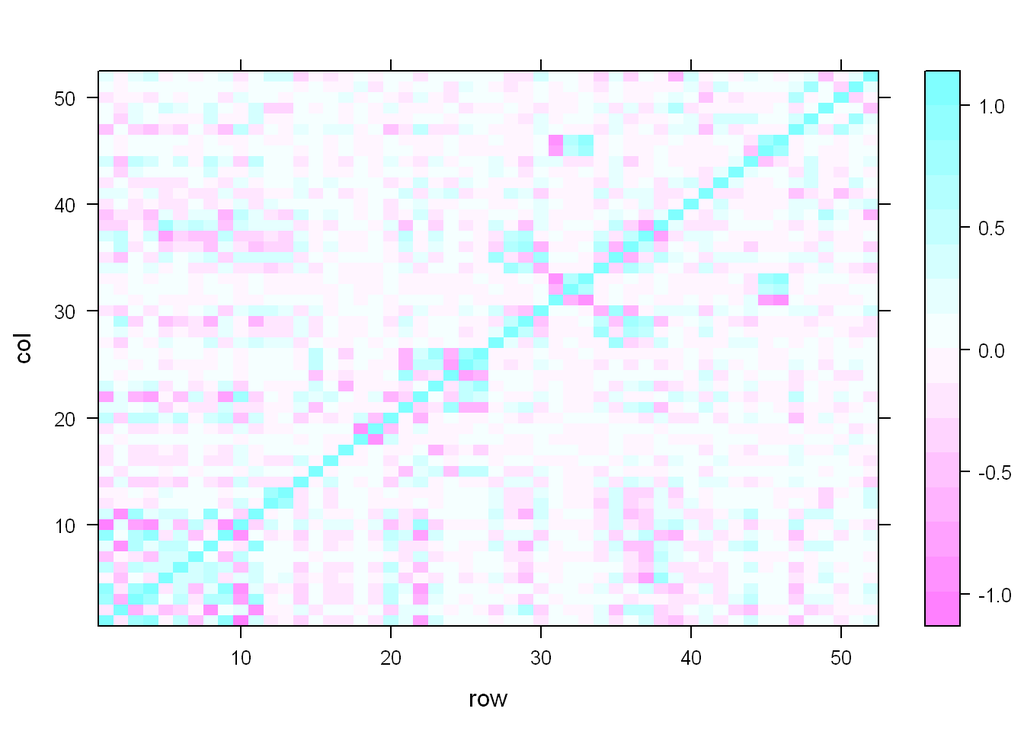

It is pretty clear that a handful of the variables are strongly correlated with each other, so I removed the ones with correlation above 80%. At the end 40 variables remained in the dataset. The observations were split into a training and testing dataset for cross validation.

Next I fit a tree on these data for examination. It showed that with this 11 variables the misclassification error rate is ~0.35.

```
##
## Classification tree:
## tree(formula = classe ~ ., data = ttrain)
## Variables actually used in tree construction:
##  [1] "pitch_forearm"        "magnet_belt_y"        "accel_forearm_z"
##  [4] "magnet_dumbbell_y"    "roll_forearm"         "magnet_dumbbell_z"
##  [7] "yaw_belt"             "accel_dumbbell_y"     "accel_forearm_x"
## [10] "yaw_dumbbell"         "total_accel_dumbbell"
## Number of terminal nodes:  19
## Residual mean deviance:  1.77 = 24280 / 13720
## Misclassification error rate: 0.3574 = 4910 / 13737
```

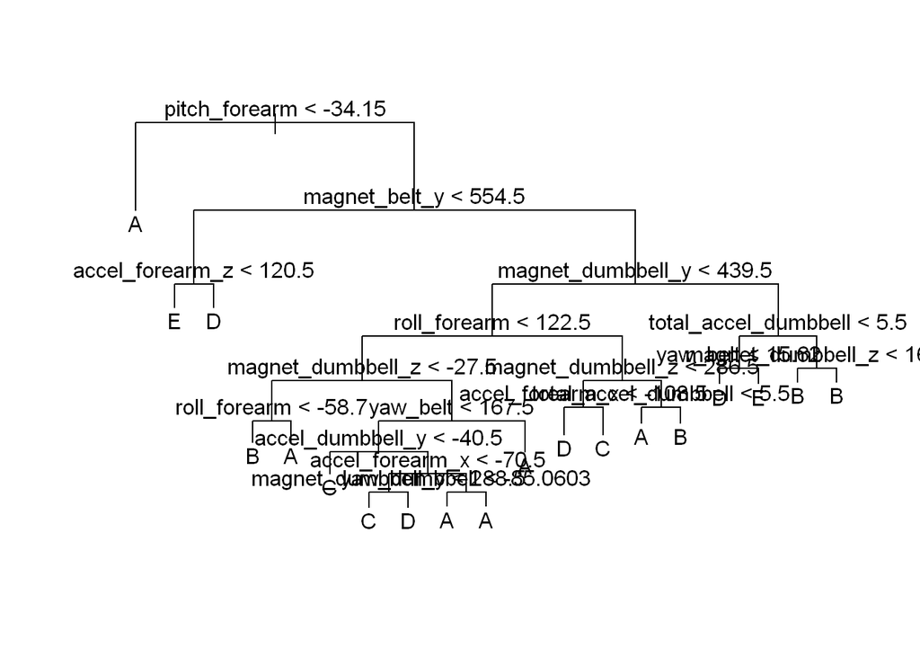

```
##
## Call:
##  randomForest(formula = classe ~ ., data = ttrain, ntree = 50)
##                Type of random forest: classification
##                      Number of trees: 50
## No. of variables tried at each split: 6
##
##         OOB estimate of  error rate: 1%
## Confusion matrix:
##      A    B    C    D    E  class.error
## A 3903    3    0    0    0 0.0007680492
## B   23 2619   15    1    0 0.0146726862
## C    0   29 2359    8    0 0.0154424040
## D    2    0   37 2207    6 0.0199822380
## E    0    1    3   10 2511 0.0055445545
```

I tested it against the observations set aside for cross validation, the accuracy was:

```
## [1] 0.9915038
```

The ~99% accuracy meant that the random forest model was very accurate, thus I used this model for the prediction of the answers that were going to be submitted for grading.